# GHGinv_playground

### KHK-inventaario, metsämaa

Samuli Launiainen 1/2024. Ihmettelyä uusimpien tilastojen valossa...

```python
import pandas as pd
import numpy as np
import matplotlib.pyplot as plt

# kasvu & poistuma; Luke tilastopalvelut
puu = pd.read_excel(r'data\Luke_Met_Poistum_03_20240106-182955.xlsx', sheet_name='data', header=0)

# Metsämaa KHK-inventaario 1990-2022; Tilastokeskus
ghg = pd.read_excel(r'data\Kasvihuonekaasupaastot_Suomessa_Tilastokeskus_060124.xlsx', sheet_name='data', header=2)
ghg  = ghg.astype(float) * 1e-3 # milj ton CO2eq a-1

# puusto (VMI8-12)
puuvarat = pd.read_excel(r'data\Luke_Met_Mvarat_puusto.xlsx', sheet_name='data', header=0)

# keskitilavuudet (VMI6-12)
tilavuudet = pd.read_excel(r'data\Luke_Met_Mvarat_keskitilavuudet.xlsx', sheet_name='data', header=0)

# yksiköt
units = {'puu': 'milj m3 a-1', 'ghg': 'milj t. CO2eq a-1', 'puusto': 'milj m3'}
```

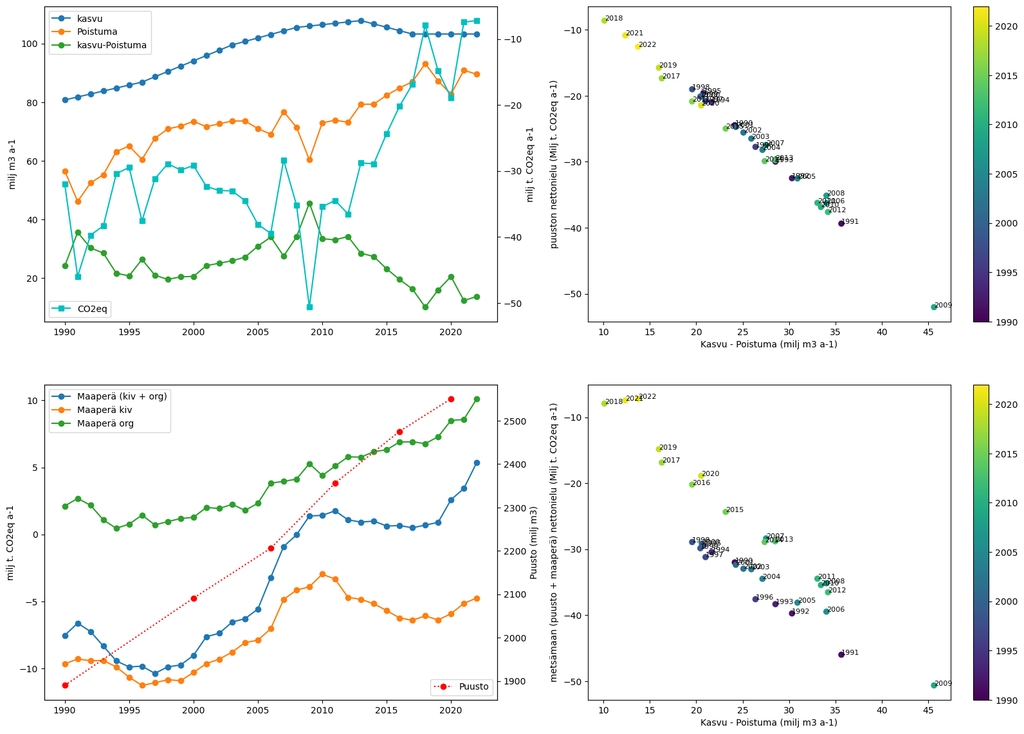

```python
fig, ax = plt.subplots(2,2, figsize=(20,14))

# kasvu - poistuma vs. metsämaan tase
x = puu['Kasvu'].values - puu['Poistuma'].values
y = ghg['CO2 tot'].values

year = puu['Vuosi'].values

s = ax[1,1].scatter(x, y, c=year)
fig.colorbar(s, ax=ax[1,1])

for k, yr in enumerate(year):
    ax[1,1].text(x[k], y[k], yr, fontsize=8)

ax[1,1].set_ylabel('metsämaan (puusto + maaperä) nettonielu (Milj t. CO2eq a-1)')
ax[1,1].set_xlabel('Kasvu - Poistuma (milj m3 a-1)')

ax[0,0].plot(year, puu['Kasvu'], 'o-', label='kasvu')
ax[0,0].plot(year, puu['Poistuma'], 'o-', label='Poistuma')
ax[0,0].plot(year, x, 'o-', label='kasvu-Poistuma')
ax[0,0].set_ylabel(units['puu'])
ax[0,0].legend()

axb = ax[0,0].twinx()
axb.plot(year, y, 's-', color = 'c', label='CO2eq')
axb.set_ylabel(units['ghg'])

axb.legend(loc=3)

# kasvu - poistuma vs. puuston tase

y = ghg['puusto kiv'].values + ghg['puusto org']

s = ax[0,1].scatter(x, y, c=year)
fig.colorbar(s, ax=ax[0,1])

for k, yr in enumerate(year):
    ax[0,1].text(x[k], y[k], yr, fontsize=8)

ax[0,1].set_ylabel('puuston nettonielu (Milj t. CO2eq a-1)')
ax[0,1].set_xlabel('Kasvu - Poistuma (milj m3 a-1)')

# aikasarja maaperäpäästöt
y1 = ghg['Maaperä kiv'].values
y2 = ghg['Maaperä org'].values

ax[1,0].plot(year, y1 + y2, 'o-', label='Maaperä (kiv + org)')
ax[1,0].plot(year, y1, 'o-', label='Maaperä kiv')
ax[1,0].plot(year, y2, 'o-', label='Maaperä org')
ax[1,0].set_ylabel(units['ghg'])
ax[1,0].legend()

axb = ax[1,0].twinx()
axb.plot(puuvarat['Vuosi'], puuvarat['Puusto'], 'o:', color = 'r', label='Puusto')
axb.set_ylabel('Puusto (' + (units['puusto']) + ')')
axb.legend(loc=4)

#fig.savefig(r'results/metsamaa_ghg_tase.png')
```

### Päähuomiot, koko metsämaa

- nettokasvu (Kasvu - poistuma, kuutiota runkopuuta) määrää puuston nettonielun (biomassan muutokset != tilavuuden muutokset mutta miten lähellä?); Oik. yläkuva
- nettokasvu määrittää myös pitkälti metsämaan (puusto + maaperä) hiilinielua; Oik. alakuva
- *mutta*: metsämaan hiilinielu esim. v. 2016 & 2020 yli 10 milj. ton CO2eqv pienepi verrattuna 1990-luvun lopun ja 2000-luvun alun vuosiin jolloin Hakkuu-Poistuma ero oli samaa luokkaa. Viimeisen 3v. aikana maaperänielusta on hävinnyt 5 milj t CO2eqv a-1. Tämä tulee pitkälti *kivennäismaan maaperän nielujen heikkenemisestä* ja *turvemaiden nettopäästöjen kasvusta*
- Puhutaan kuinka *hakkuut määrää hiilinielun* (true) ja kuinka *hakkuita pitää rajoittaa*. Mutta ymmärretäänkö mitä maaperässä tapahtuu ja *kuvaako YASSO07 (kivennäismaat)* ja *uusi Alm et al. 2023 turvemaiden maaperän hiilitasemalli* maaperäpäästöjen käyttäytymisen oikein? Onko tätä a) tajuttu, b) huomioitu, c) asiaa kriittisesti ajateltu?
- 10 milj. ton CO2eqv a-1 vastaa karkeasti noin 10 milj m3 a-1 muutosta hakkuutasossa. Mikä on hintalappu?

### Suomessa puuta enemmän kuin koskaan mutta laskenta näyttää, että maaperän nettonielut heikkenee / nettopäästöt kasvaa *sekä* kivennäis- että turvemailla. Mikä ihme vaikuttaa taustalla?

- karikesyöte $\propto M_{biomass}$
- elävän biomassan karikesyöteen todelliset muutokset (kivennäismaat: hiilisyöte, AWEN-suhde; turvemaat: hiilisyöte + PPA kasvu)? Näitä voi olla puuston rakenteen ja lajisuhteiden muutokset? Männiköiden keskitilavus kasvussa, kuusella ja lehtipuilla ei trendiä. Vai onko taustalla laskennalliset muutokset ja epäkonsistentit menetelmät (VMI8--VMI12/13; different biomass expansion factors used to estimate compartmental biomasses for each NFI, biomasses linearly interpolated between NFI's)?
- hakkuiden aiheuttaman karikesyötteen lisääntyminen / pieneneminen (hakkuumäärät, energiapuun korjuu)?
- ilmastotrendit (30v liukuva keskiarvo keskilämpötila, vuosisadanta, turvemailla kasvukauden keskilämpötila)? Turvemailla uudesta mallista syntyy järjettömän voimakas 'hajotuksen' lämpötilariippuvuus (Q10 ~4-12).
- kivennäismailla Yasson steady-state alkutila laskettu käyttäen 1970-luvun karikesyötteitä ja 1960-1990 sääoloja. Voiko aiheuttaa oskillaatiota?

### *Puuston nielun* suhde nettokasvuun (kasvu - poistuma)

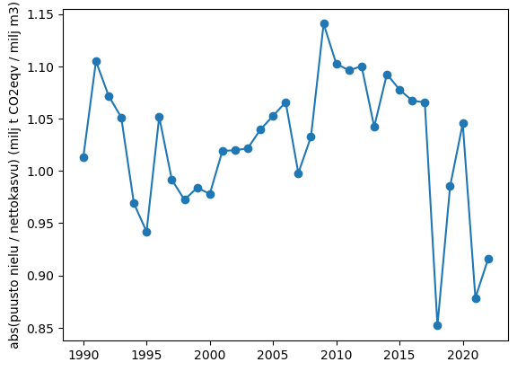

```python
x = puu['Kasvu'].values - puu['Poistuma'].values # milj m3 a-1; runkotilavuuden muutos
y = ghg['puusto kiv'].values + ghg['puusto org'] # milj t CO2eqv; perustuu biomassoihin != runkotilavuus

plt.figure()
plt.plot(year, abs(y/x), 'o-')
plt.ylabel('abs(puusto nielu / nettokasvu) (milj t CO2eqv / milj m3)')
```

- kasvu 2018-2022 kuvissa extrapoloitu; oletus 103 milj m3 a-1 kuten 2017
- voiko metsikkörakenteen muutos aiheuttaa nettokasvu / puuston nielu -suhteeseen a.o. vaihtelun; allometria?? Vai eikö joku täsmää?
- miksi puuston nielun suhde nettokasvuun PARANI 1998--2010, jonka jälkeen tasaantui ja heitellyt viimeisinä vuosina? 2018, 2021 & 2022 yli 10% PIENEMPI kuin keskiarvo. *HUOM: kasvu 2018-2022 on oletettu samaksi (103 milj m3 a-1) kuin vuonna 2017*
- hiilitase perustuu biomassan muutoksiin, nettokasvu taas runkotilavuuden muutokseen
- biomass expansion factors (BEF's, vol --> biomassa) inventaariolaskennassa erilaiset *poistumalle* ja *elävälle puustolle*, oletettavasti koska läpimittajakauma on erilainen
- Alla pelatattu Lehtonen et al. 2004 ForEco BEF'eilla ymmärtääkseni kuinka epälineaarisia biomassat voi olla tilavuuden suhteen

```python
def BEF(vol: float, species: str):
    """
    Lehtonen et al. 2004 ForEco Table 6-8: DM = aV**b [tons DM ha-1]
    Args:
        vol: stem volume (m3 ha-1)
        species: 'pine', 'spruce', 'decid'
    Returns:
        dataframe [units: tons DM ha-1]
    """
    # ln(a): [stem, foliage, branches, branches dead, bark, stump, roots coarse, roots small, total, total ABVG]
    p = {'pine': {'a': [-1.1576, -2.2532, -2.3012, -3.9252, -2.8289, -3.1697, -3.3197, -2.6589, -0.3453, -0.5632],
                  'b': [1.0444, 0.7802, 0.9504, 0.9056, 0.8842, 1.0171, 1.1400, 0.8686, 0.9989, 0.9932]},
         'spruce': {'a': [-1.1154, -1.4772, -1.4447, -4.1336, -2.8200, -2.9410, -2.8028, -2.1205, 0.0230, -0.2086],
                    'b': [1.0298, 0.7718, 0.8642, 0.9141, 0.9221, 0.9750, 1.0810, 0.7707, 0.9511, 0.9478]},
        # ln(a): [stem, branches, branches dead, bark, total ABVG]
         'decid': {'a': [-0.9818, -2.6242, -3.8654, -2.5764, -0.4852],
                   'b': [1.0062, 1.0534, 0.8197, 0.9621, 0.9921]}
        }

    if species != 'decid':
        cols = ['stem', 'foliage', 'branches', 'branches dead', 'bark',
                'stump', 'roots coarse', 'roots small', 'total', 'total ABVG']
        df = pd.DataFrame(columns=cols, data=np.zeros((len(vol), len(cols))))
    else:
        cols = ['stem', 'branches', 'branches dead', 'bark', 'total ABVG']
        df = pd.DataFrame(columns=cols, data=np.zeros((len(vol), len(cols))))

    # parameters
    a = np.exp(np.array(p[species]['a']))
    b = np.array(p[species]['b'])
    k = 0
    for c in df.columns:
        df[c] = a[k] * vol **b[k]
        k += 1

    return df
```

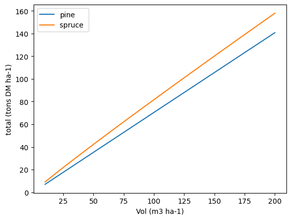

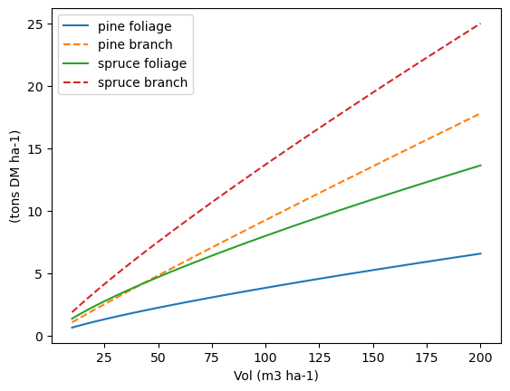

```python
vol = np.linspace(10, 200, 100)

bm_pine = BEF(vol, species='pine')
bm_spruce = BEF(vol, species='spruce')
bm_decid = BEF(vol, species='decid')

plt.figure()
plt.plot(vol, bm_pine['total'] ,'-', label='pine')
plt.plot(vol, bm_spruce['total'], '-', label='spruce ')
#plt.plot(vol, bm_decid['total ABVG'], '--', label='decid')
plt.legend()
plt.ylabel('total (tons DM ha-1)')
plt.xlabel('Vol (m3 ha-1)')

plt.figure()
plt.plot(vol, bm_pine['foliage'], '-', label='pine foliage')
plt.plot(vol, bm_pine['branches'] + bm_pine['branches dead'] , '--', label='pine branch')
plt.plot(vol, bm_spruce['foliage'], '-', label='spruce foliage')
plt.plot(vol, bm_spruce['branches'] + bm_spruce['branches dead'] , '--', label='spruce branch')
plt.legend()
plt.ylabel('(tons DM ha-1)')
plt.xlabel('Vol (m3 ha-1)')
```

### Miksi maaperänielu pienee kivennäismailla?

- karikesyöte täytyy kasvaa $\propto M_{biomass}$
- karikesyöte täytyy kasvaa $\propto poistuma$ koska hakkuutähteet & luontainen poistuma. Eli näiden perusteella karikesyötteen olettaisi *kasvaneen*
- nettokasvu on ollut lähinnä mäntyä; pieneneekö karikesyöte tai muuttuuko sen AWEN jakauma koska lajisuhteet muuttuu?
- aluskasvillisuuden karikesyöte ei riipu puustosta (NIR-raportti), mikä on sinänsä omituista... turvemailla kun pienenee lineaarisesti PPA funktiona.
- YASSO07 ei erottele kasvupaikkoja tai karikkeiden laatua (pl. AWEN ja coarse residue dimension)
- hajotuksen lämpötila- tai kosteusvasteet ei voi olla merkittäviä tekijöitä? Kosteusvastetta ei käytännössä ole kuten alta huomataan...

### Isot kysymykset:

1) Onko YASSOn responssi säätrendeihin ja vaihteluun karikesyötteessä uskottava? 2) Onko maaperän pienenevä hiilinielu uskottava trendi parhaan ymmärryksen ja havaintojen valossa? 3) Reagoiko inventaariolaskenta (lähinnä maaperän taseen laskenta) uskottavasti metsänhoidossa / metsän käytössä tapahtuviin muutoksiin? Tämä on se 10 milj m3 a-1 tai 10 milj t CO2eq a-1 ja xxx Mrd € kysymys. 4) Keskustelu polarisoituu turvemaihin, joiden uusi laskentamenetelmä on omituinen. Mutta - onko kaikki ok kivennäismailla(kaan)?

```python
def yasso_envmod(T:float, P:float):
    # T - annual mean temperature (degC)
    # P - annual precipitation (m)

    # scandinavian parameterset used in NIR
    b1 = 0.0885 #C-1
    b2 = -0.0023 #C-2
    gamma = -2.94 #m-1

    # Tuomi et al. 2008
    #b1 = 0.076
    #b2 = -0.00089
    #gamma = -1.27 #m-1

    fT = np.exp(b1*T + b2*T**2)
    fP = (1.0 - np.exp(gamma * P))

    return fT, fP, fT*fP
```

```
Climate trend effect on decomposition: South 1.10, North 1.11
approx Q10 2.07
```

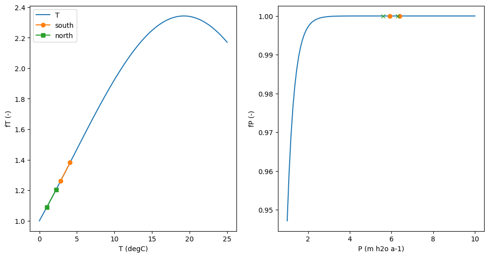

```python
# säädata, 30v liukuvat keskiarvot (Alm et al. 2023 Fig. 4 1990 & 2020 arvot digitoitu

Tsouth = np.array([2.83, 4.09])
Tnorth = np.array([0.97, 2.23])
Psouth = np.array([5.93, 6.39]) # m h2o a-1
Pnorth = np.array([5.6, 6.29]) # m h2o a-1

T = np.linspace(0.0, 25.0, 100)
P = np.linspace(1, 10, 100)

fT, fP, fClim = yasso_envmod(T, P)
fTs, fPs, fClims = yasso_envmod(Tsouth, Psouth)
fTn, fPn, fClimn = yasso_envmod(Tnorth, Pnorth)

fig, ax = plt.subplots(1,2, figsize=(12,6))

ax[0].plot(T, fT, '-', label='T')
ax[0].plot(Tsouth, fTs, 'o-', label='south')
ax[0].plot(Tnorth, fTn, 's-', label='north')
ax[0].set_ylabel('fT (-)')
ax[0].set_xlabel('T (degC)')
ax[0].legend()

ax[1].plot(P, fP, '-', label='P')
ax[1].plot(Psouth, fPs, 'o')
ax[1].plot(Pnorth, fPn, 'x')
ax[1].set_ylabel('fP (-)')
ax[1].set_xlabel('P (m h2o a-1)')


print('Climate trend effect on decomposition: South %.2f, North %.2f ' % (fClims[1]/fClims[0], fClimn[1]/fClimn[0]))

Q10 = (fTs[1]/fTs[0])**(10 / (Tsouth[1] - Tsouth[0]))

print('approx Q10 %.2f' % Q10)
```

### Climate effect in Yasso07

- is equal to linear temperature response, for our conditions equals Q10~2.1
- precipitation has no influence in Finnish conditions
- $\Delta T \simeq 1.3...1.4$ degC from 1990 to 2022 has increased decomposition rates $k$ by ca. 10\%
- must code and play with Yasso...
- soil CO2 balance = litter input - decomposition small residual of two large fluxes; hard to know how much is 10\% increase in decomposition...